# データ解析論II第4講

## 目次

## 前回の復習

## 単純傾斜分析（教科書，p99）

- 分散分析で交互作用が有意であったときに下位検定として単純効果の検定が行われる．
  - 具体的にどこの群とどこの群の間に，統計的な有意差が認められるか．
- 同様に回帰分析の枠組みでも下位検定として「単純傾斜分析」を行う．
  - 中心化した得点に対して，1標準偏差を引いた変数（-1SD）と，1標準偏差足した変数(+1SD)を用いて分析する．
- 1SDを引くとソーシャルサポートが多い場合を分析でき，1SDを足すとソーシャルサポートが少ない場合を分析できる．
  - \(y = ax\)をx軸方面に+pだけ平行移動させるときに\(y = a(x-p)\)になるのと同じ考え方．

## バーンアウト2に対するソーシャルサポートが多い場合

\(\operatorname{バーンアウト2} = \alpha + \beta_{1}(\operatorname{バーンアウト1中心})\\ + \beta_{2}(\operatorname{ストレス中心}) +\beta_{3}(\operatorname{サポート中心-SD(サポート中心)})\\ + \beta_{4}(\operatorname{ストレス中心}) \times( \operatorname{サポート中心-SD(サポート中心)}) + \epsilon\\ \) \(\operatorname{バーンアウト2} = \alpha + \beta_{1}(\operatorname{バーンアウト1中心})\\ + \{ {\beta_2} + \beta_4 \times (\operatorname{サポート中心-SD(サポート中心)})\} \times (\operatorname{ストレス中心}) \\ +\beta_{3}(\operatorname{サポート中心-SD(サポート中心)}) + \epsilon\)

- \(\{ {\beta_2} + \beta_4 \times (\operatorname{サポート中心-SD(サポート中心)})\} \times(\operatorname{ストレス中心})\)が単純傾斜と呼ばれる．
- サポート中心の値がSD(サポート中心)であった場合，次のモデルになる．

\(\operatorname{バーンアウト2} = \alpha + \beta_{1}(\operatorname{バーンアウト1中心}) + \beta_{2}(\operatorname{ストレス中心}) + \epsilon\\ \)

- この時，単純傾斜は\({\beta_2}\)となり，\({\beta_2} \neq 0\)であればソーシャルサポートが多い場合に，バーンアウトに対するストレス経験の効果が認められる．
- この時，バーンアウト2の推定値は以下の通りとなる．

\(\operatorname{バーンアウト2の推定値} = \alpha + \beta_{2}(\operatorname{ストレス中心})\)

- また，同様にストレス中心をSD(ストレス)or-SD(ストレス)とすれば，ソーシャルサポートが多く，ストレス経験が多いor少ないときのバーンアウト2の値を導出することができる．

## バーンアウト2に対するソーシャルサポートが少ない場合

- 基本的に同じロジックである

\(\operatorname{バーンアウト2} = \alpha + \beta_{1}(\operatorname{バーンアウト1中心})\\ + \beta_{2}(\operatorname{ストレス中心}) + \beta_{3}(\operatorname{サポート中心-(-SD(サポート中心))})\\ + \beta_{4}(\operatorname{ストレス中心} \times \operatorname{サポート中心-(-SD(サポート中心))}) + \epsilon\) \(\operatorname{バーンアウト2} = \alpha + \beta_{1}(\operatorname{バーンアウト1中心})\\ + \{ {\beta_2} + \beta_4 \times (\operatorname{サポート中心+SD(サポート中心)})\} \times (\operatorname{ストレス中心}) \\ +\beta_{3}(\operatorname{サポート中心+SD(サポート中心)}) + \epsilon\)

- \(\{ {\beta_2} + \beta_4 \times (\operatorname{サポート中心+SD(サポート中心)})\} \times(\operatorname{ストレス中心})\)が単純傾斜と呼ばれる．
- サポート中心の値が-SD(サポート中心)であった場合，次のモデルになる．

\(\operatorname{バーンアウト2} = \alpha + \beta_{1}(\operatorname{バーンアウト1中心}) + \beta_{2}(\operatorname{ストレス中心}) + \epsilon\\ \)

- この時，単純傾斜は\({\beta_2}\)となり，\({\beta_2} \neq 0\)であればソーシャルサポートが少ない場合に，バーンアウトに対するストレス経験の効果が認められる．
- この時，バーンアウト2の推定値は以下の通りとなる．

\(\operatorname{バーンアウト2の推定値} = \alpha + \beta_{2}(\operatorname{ストレス中心})\)

- また，同様にストレス中心をSD(ストレス)or-SD(ストレス)とすれば，ソーシャルサポートが少なく，ストレス経験が多いor少ないときのバーンアウト2の値を導出することができる．

## バーンアウト2に対するソーシャルサポートが多い場合

```r
# サポートの中心化
ストレス$サポート中心High <- ストレス$サポート中心 -
  sd(ストレス$サポート中心)

model4_high <- lm(バーンアウト2 ~ バーンアウト1中心+
                          ストレス中心* サポート中心High, ストレス)
```

```r
summary(model4_high)
```

```
##
## Call:
## lm(formula = バーンアウト2 ~ バーンアウト1中心 +
##     ストレス中心 * サポート中心High, data = ストレス)
##
## Residuals:
##      Min       1Q   Median       3Q      Max
## -1.43353 -0.17514  0.00955  0.21465  1.16380
##
## Coefficients:
##                                Estimate Std. Error t value Pr(>|t|)
## (Intercept)                    2.692885   0.028283  95.213   <2e-16 ***
## バーンアウト1中心              0.571517   0.044378  12.878   <2e-16 ***
## ストレス中心                   0.003473   0.044090   0.079   0.9373
## サポート中心High              -0.110063   0.048636  -2.263   0.0244 *
## ストレス中心:サポート中心High -0.155585   0.061210  -2.542   0.0115 *
## ---
## Signif. codes:  0 '***' 0.001 '**' 0.01 '*' 0.05 '.' 0.1 ' ' 1
##
## Residual standard error: 0.3407 on 295 degrees of freedom
## Multiple R-squared:  0.4293, Adjusted R-squared:  0.4216
## F-statistic: 55.48 on 4 and 295 DF,  p-value: < 2.2e-16
```

\[ \operatorname{バーンアウト2} = 2.69 + 0.57(\operatorname{バーンアウト1中心})\\ + 0(\operatorname{ストレス中心}) - 0.11(\operatorname{サポート中心High})\\ - 0.16(\operatorname{ストレス中心} \times \operatorname{サポート中心High}) + \epsilon \]

- ストレス中心は偏回帰係数が0であり，p>.05であった．
- ソーシャルサポートが多い場合には，ストレス経験とバーンアウトの間に関係がない．

## バーンアウト2に対するソーシャルサポートが少ない場合

```r
# サポートの中心化
ストレス$サポート中心low <- ストレス$サポート中心 + sd(ストレス$サポート中心)

model4_low <- lm(バーンアウト2 ~ バーンアウト1中心 +
                         ストレス中心* サポート中心low, ストレス)
```

```r
summary(model4_low)
```

```
##
## Call:
## lm(formula = バーンアウト2 ~ バーンアウト1中心 +
##     ストレス中心 * サポート中心low, data = ストレス)
##
## Residuals:
##      Min       1Q   Median       3Q      Max
## -1.43353 -0.17514  0.00955  0.21465  1.16380
##
## Coefficients:
##                              Estimate Std. Error t value Pr(>|t|)
## (Intercept)                   2.78647    0.02891  96.383  < 2e-16 ***
## バーンアウト1中心             0.57152    0.04438  12.878  < 2e-16 ***
## ストレス中心                  0.13577    0.04192   3.239  0.00134 **
## サポート中心low              -0.11006    0.04864  -2.263  0.02436 *
## ストレス中心:サポート中心low -0.15558    0.06121  -2.542  0.01154 *
## ---
## Signif. codes:  0 '***' 0.001 '**' 0.01 '*' 0.05 '.' 0.1 ' ' 1
##
## Residual standard error: 0.3407 on 295 degrees of freedom
## Multiple R-squared:  0.4293, Adjusted R-squared:  0.4216
## F-statistic: 55.48 on 4 and 295 DF,  p-value: < 2.2e-16
```

\[ \operatorname{バーンアウト2} = 2.79 + 0.57(\operatorname{バーンアウト1中心}) \\ + 0.14(\operatorname{ストレス中心}) - 0.11(\operatorname{サポート中心low}) \\ - 0.16(\operatorname{ストレス中心} \times \operatorname{サポート中心low}) + \epsilon \]

- ストレス中心は偏回帰係数が0.14であり，p<.05であった．
- ソーシャルサポートが少ない場合には，ストレス経験とバーンアウトの間に正の相関がある．

## 一般化線形モデル

## 一般化線形モデルとは？

- 分散として正規分布以外の分布を仮定したモデル
  - 今までやってきたt検定や回帰分析は**「一般線形モデル」**として，正規分布を仮定したモデルである．
- 一般化線形モデルを使うべき例：
  - ロジスティック回帰：タイタニック号のどのような乗客が生き残る可能性が高かったか．
    - 応答変数：死ぬか生きるか
  - ポアゾン回帰：データの個数がテーマになる場合
    - 応答変数：0以上X未満のデータなど

## ロジスティック回帰分析

- 回帰分析と類似しているが「応答変数が2値」の時に利用する．
  - 説明変数は数値データでも因子データでも構わない．
- ロジスティック回帰分析は様々な応用がある．
  - 2値変数：二項ロジスティック回帰分析
  - 3項（カテゴリ）以上：多項ロジスティック回帰分析
  - 順序変数：順序ロジスティック回帰分析

## データ概要（教科書p.262）

```r
library(readr)
空き巣調査 <- read_csv("../data/空き巣調査.csv",
    locale = locale(encoding = "SHIFT-JIS"))
```

- 前回のデータの読み込み方を思い出しておきましょう．
- 「空き巣」：空き巣の被害の有無
- 「不在時間」：平日9時から18時の不在時間
- 「会話」：近隣住民との会話の回数
- 「築年数」：住居の築年数
- 「セキュリティ」：ホームセキュリティ会社のサービスへの加入・非加入
- 「飼い犬」：飼い犬の有無

## 回帰分析とロジスティック回帰分析の違い

- 回帰分析の目的：目的変数の値自体を予測・説明する
- ロジスティック回帰分析：2値カテゴリに分類される指標について，カテゴリAからカテゴリBとなる確率を説明する．
  - 基準カテゴリを設定して，もう一方にどのように変化するのかを明らかにする．
  - ダミー変数を作って，0が1に変化する確率を求める．

## データを変えよう

- ダミー変数を作ります．
  - 空き巣・セキュリティ・飼い犬をダミー変数にしましょう．
- 先に「questionr」というパッケージを入れておこう．
  - これを入れておくと，順番を入れ替えたり，変数を変えるのが非常に便利になる．
  - Addinsからクリックだけで作業ができる．

```r
# install.packages("questionr")
```

- インストール後の動きは動画で確認してください．

```r
## Recoding 空き巣調査$空き巣 into 空き巣調査$空き巣01
空き巣調査$空き巣01 <- recode(空き巣調査$空き巣,
  "あり" = "1",
  "なし" = "0"
)
空き巣調査$空き巣01 <- as.numeric(空き巣調査$空き巣01)
```

```r
## Recoding 空き巣調査$セキュリティ into 空き巣調査$セキュリティ01
空き巣調査$セキュリティ01 <- recode(空き巣調査$セキュリティ,
  "加入" = "1",
  "非加入" = "0"
)
空き巣調査$セキュリティ01 <- as.numeric(空き巣調査$セキュリティ01)
```

```r
## Recoding 空き巣調査$飼い犬 into 空き巣調査$飼い犬01
空き巣調査$飼い犬01 <- recode(空き巣調査$飼い犬,
  "なし" = "0",
  "あり" = "1"
)
空き巣調査$飼い犬01<- as.numeric(空き巣調査$飼い犬01)
```

## 簡単なモデルから

- 対立仮説：セキュリティの有無によって，空き巣の数を変化させることができる．
- 帰無仮説：セキュリティの有無によって，空き巣の数を変化させることができるとはいえない．

## 参考：

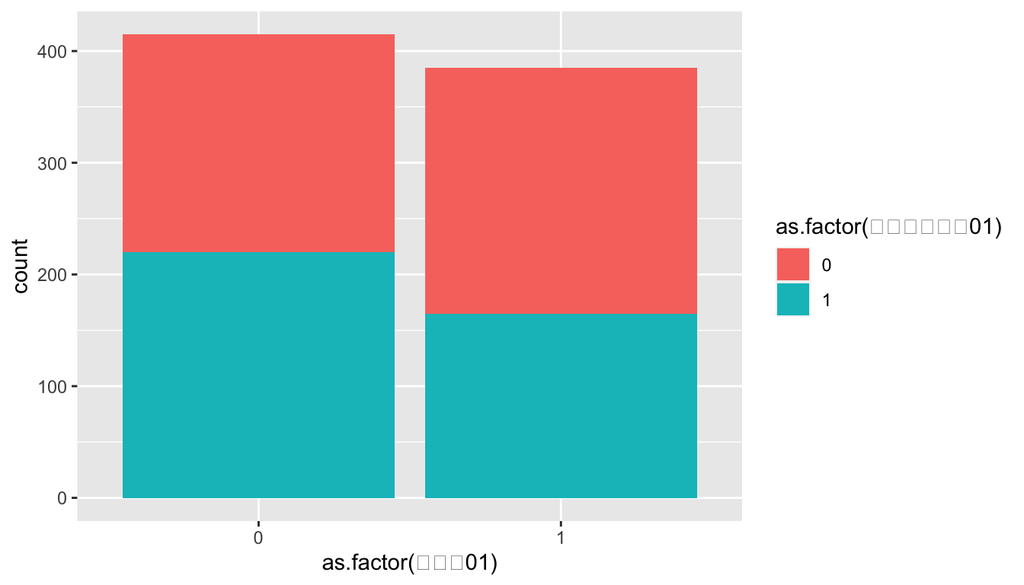

```r
library(ggplot2)
空き巣調査%>%
  ggplot(aes(x=as.factor(空き巣01),
             fill=as.factor(セキュリティ01)),
         stat="count")+geom_bar()
```

## 分析

```r
model1_logi <- glm(空き巣01 ~ セキュリティ01,
                      family = "binomial", data=空き巣調査)
```

- 今回の分析モデル

\[ \begin{aligned} \operatorname{空き巣01}_{\operatorname{1}} &\sim B\left(\operatorname{prob} = \hat{P},\operatorname{size} = 800\right) \\ \log\left[ \frac {\hat{P}}{1 - \hat{P}} \right] &= \alpha + \beta_{1}(\operatorname{セキュリティ01}) + \epsilon \end{aligned} \]

```r
summary(model1_logi)
```

```
##
## Call:
## glm(formula = 空き巣01 ~ セキュリティ01, family = "binomial",
##     data = 空き巣調査)
##
## Deviance Residuals:
##    Min      1Q  Median      3Q     Max
## -1.229  -1.058  -1.058   1.127   1.302
##
## Coefficients:
##                Estimate Std. Error z value Pr(>|z|)
## (Intercept)     0.12063    0.09835   1.226  0.22003
## セキュリティ01 -0.40831    0.14241  -2.867  0.00414 **
## ---
## Signif. codes:  0 '***' 0.001 '**' 0.01 '*' 0.05 '.' 0.1 ' ' 1
##
## (Dispersion parameter for binomial family taken to be 1)
##
##     Null deviance: 1107.9  on 799  degrees of freedom
## Residual deviance: 1099.6  on 798  degrees of freedom
## AIC: 1103.6
##
## Number of Fisher Scoring iterations: 3
```

\[ \begin{aligned} \operatorname{空き巣01}_{\operatorname{1}} &\sim B\left(\operatorname{prob} = \hat{P},\operatorname{size} = 800\right) \\ \log\left[ \frac {\hat{P}}{1 - \hat{P}} \right] &= 0.12 - 0.41(\operatorname{セキュリティ01}) + \epsilon \end{aligned} \]

```r
exp(model1_logi$coefficients)
```

```
##    (Intercept) セキュリティ01
##      1.1282051      0.6647727
```

## ロジスティック回帰分析をプロットしよう

```r
graph1<-空き巣調査 %>% ggplot(aes(x=セキュリティ01, y=空き巣01)) +
  geom_point() +
  stat_smooth(method="glm",
              method.args=list(family="binomial"), se=TRUE)+
  geom_jitter(height=0.01, width = 0.01)+
  theme_bw()
```

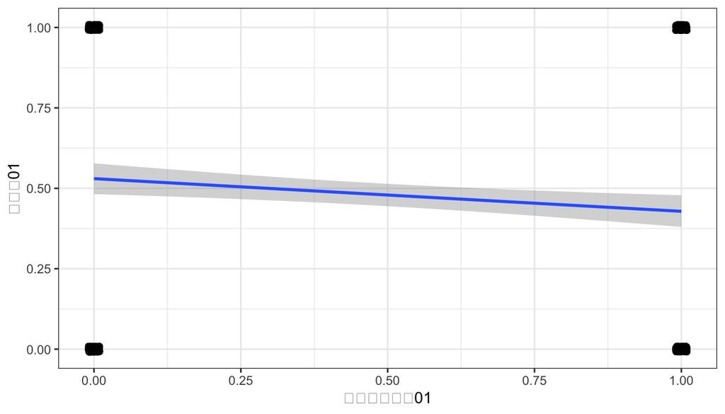

```r
graph1
```

## macの方はコチラを使ってください．

```r
graph1_mac<-空き巣調査 %>% ggplot(aes(x=セキュリティ01,
                                 y=空き巣01)) +
  geom_point() +
  stat_smooth(method="glm",
              method.args=list(family="binomial"), se=TRUE)+
  geom_jitter(height=0.01, width = 0.01)+
  theme_bw(base_family = "YuGo-Medium")
```

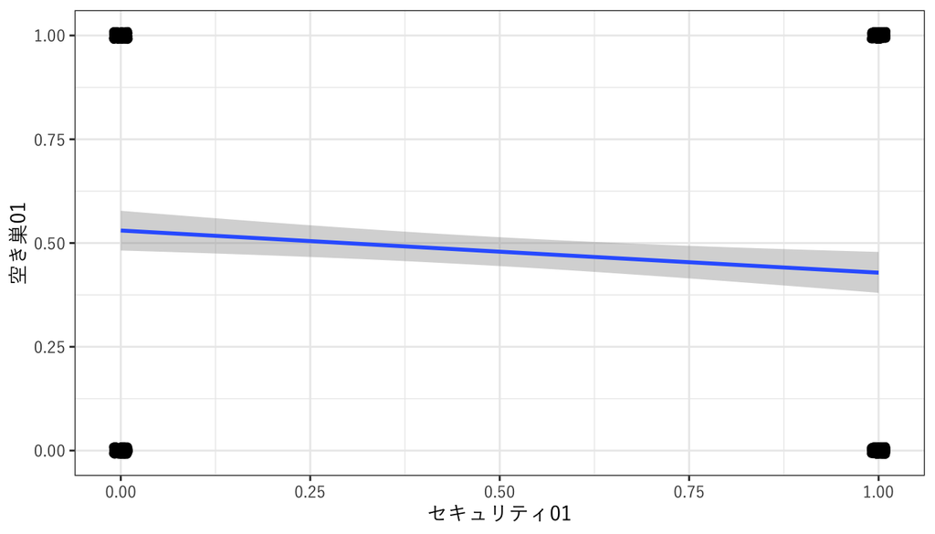

```r
graph1_mac
```

## より複雑なモデルへ

## 分析

- さらに，不在時間の影響について検討する．

```r
model2_logi <- glm(空き巣01 ~ 不在時間 + セキュリティ01,
                      family = "binomial", data=空き巣調査)
```

- 今回の分析モデル

\[ \begin{aligned} \operatorname{空き巣01}_{\operatorname{1}} &\sim B\left(\operatorname{prob} = \hat{P},\operatorname{size} = 800\right) \\ \log\left[ \frac {\hat{P}}{1 - \hat{P}} \right] &= \alpha + \beta_{1}(\operatorname{不在時間}) + \beta_{2}(\operatorname{セキュリティ01}) + \epsilon \end{aligned} \]

```r
summary(model2_logi)
```

```
##
## Call:
## glm(formula = 空き巣01 ~ 不在時間 + セキュリティ01,
##     family = "binomial", data = 空き巣調査)
##
## Deviance Residuals:
##     Min       1Q   Median       3Q      Max
## -2.0261  -1.0308  -0.4938   1.0528   1.9893
##
## Coefficients:
##                Estimate Std. Error z value Pr(>|z|)
## (Intercept)     -1.5273     0.1954  -7.818 5.37e-15 ***
## 不在時間         0.4054     0.0410   9.889  < 2e-16 ***
## セキュリティ01  -0.5296     0.1548  -3.422 0.000621 ***
## ---
## Signif. codes:  0 '***' 0.001 '**' 0.01 '*' 0.05 '.' 0.1 ' ' 1
##
## (Dispersion parameter for binomial family taken to be 1)
##
##     Null deviance: 1107.91  on 799  degrees of freedom
## Residual deviance:  980.99  on 797  degrees of freedom
## AIC: 986.99
##
## Number of Fisher Scoring iterations: 4
```

\[ \begin{aligned} \operatorname{空き巣01}_{\operatorname{1}} &\sim B\left(\operatorname{prob} = \hat{P},\operatorname{size} = 800\right) \\ \log\left[ \frac {\hat{P}}{1 - \hat{P}} \right] &= -1.53 + 0.41(\operatorname{不在時間}) \\ &- 0.53(\operatorname{セキュリティ01}) + \epsilon \end{aligned} \]

- セキュリティがあろうと無かろうと，不在時間が長いと空き巣に合う可能性が高まる．

```r
graph2<-空き巣調査 %>%
  ggplot(aes(x=不在時間, y=空き巣01)) +
  geom_point() +
  stat_smooth(method="glm",
              method.args=list(family="binomial"),
              se=TRUE)+
  facet_grid(.~ セキュリティ01)+
  geom_jitter(height=0.01, width = 0.01)+
  theme_bw()
```

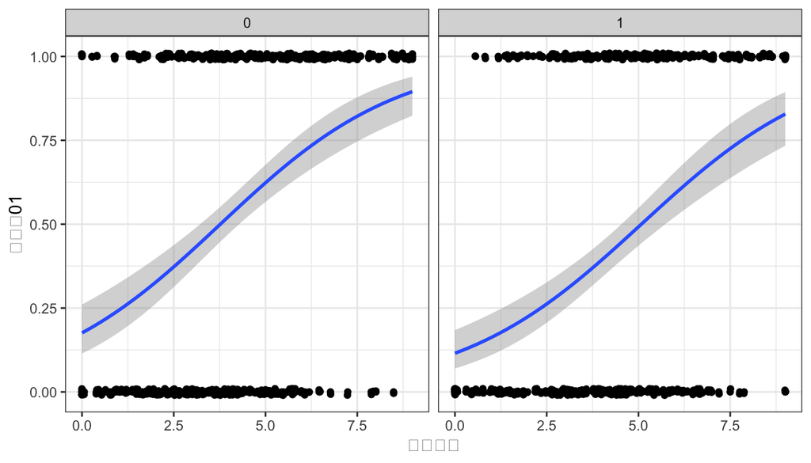

```r
graph2
```

## macの方はコチラを使ってください．

```r
graph2_mac<-空き巣調査 %>%
  ggplot( aes(x=不在時間, y=空き巣01), ) + geom_point() +
  stat_smooth(method="glm",
              method.args=list(family="binomial"),
              se=TRUE)+
  facet_grid(.~ セキュリティ01)+
  geom_jitter(height=0.01, width = 0.01)+
  theme_bw(base_family = "YuGo-Medium")
```

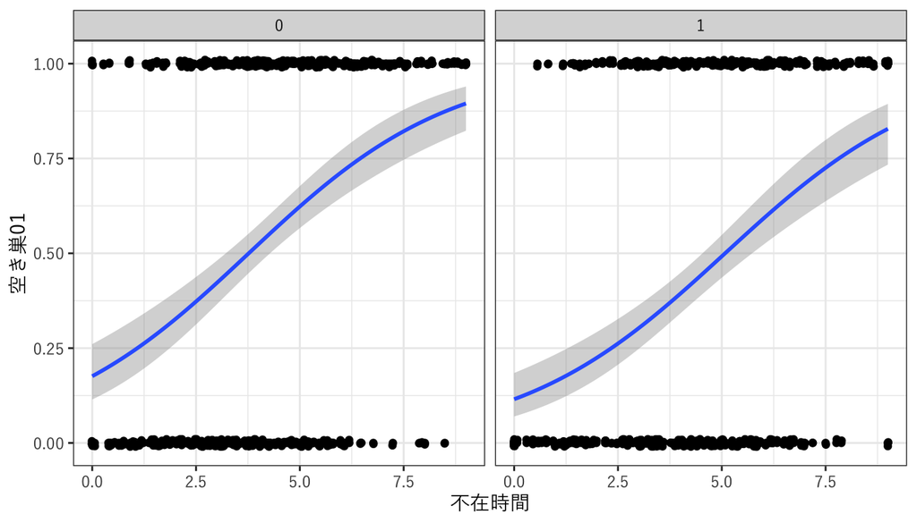

```r
graph2_mac
```

## モデル選択

- セキュリティだけのモデルと，不在時間の入ったモデルだと，どちらが妥当性が高いか検証しよう．

```r
anova(model1_logi, model2_logi, test = "Chisq")
```

```
## Analysis of Deviance Table
##
## Model 1: 空き巣01 ~ セキュリティ01
## Model 2: 空き巣01 ~ 不在時間 + セキュリティ01
##   Resid. Df Resid. Dev Df Deviance  Pr(>Chi)
## 1       798    1099.64
## 2       797     980.99  1   118.66 < 2.2e-16 ***
## ---
## Signif. codes:  0 '***' 0.001 '**' 0.01 '*' 0.05 '.' 0.1 ' ' 1
```

- 最後の`test = "Chisq"`は\(\chi^2\)分布を用いてモデルの妥当性を評価してほしいという指定をしている．
- この結果，不在時間の入ったモデルの方が妥当性が高いと考えられる．
- ただ，他にも変数があるので，全ての要因を入れてからモデル選択をしよう．

## 分析

- フルモデル（全ての変数が入ったモデル）．

```r
modelfull_logi <- glm(空き巣01 ~ 不在時間+ 会話 + 築年数
                         + セキュリティ01 + 飼い犬01,
                      family = "binomial", data=空き巣調査)
```

- 今回の分析のフルモデル

\[ \begin{aligned} \operatorname{空き巣01}_{\operatorname{1}} &\sim B\left(\operatorname{prob} = \hat{P},\operatorname{size} = 800\right) \\ \log\left[ \frac {\hat{P}}{1 - \hat{P}} \right] &= \alpha + \beta_{1}(\operatorname{不在時間}) + \beta_{2}(\operatorname{会話}) \\ &+ \beta_{3}(\operatorname{築年数}) + \beta_{4}(\operatorname{セキュリティ01}) + \beta_{5}(\operatorname{飼い犬01}) + \epsilon \end{aligned} \]

```r
summary(modelfull_logi)
```

```
##
## Call:
## glm(formula = 空き巣01 ~ 不在時間 + 会話 + 築年数 +
##     セキュリティ01 + 飼い犬01, family = "binomial",
##     data = 空き巣調査)
##
## Deviance Residuals:
##    Min      1Q  Median      3Q     Max
## -2.079  -1.002  -0.496   1.019   2.173
##
## Coefficients:
##                 Estimate Std. Error z value Pr(>|z|)
## (Intercept)    -0.941239   0.278842  -3.376 0.000737 ***
## 不在時間        0.393992   0.041904   9.402  < 2e-16 ***
## 会話           -0.550249   0.130741  -4.209 2.57e-05 ***
## 築年数          0.005839   0.010774   0.542 0.587818
## セキュリティ01 -0.548210   0.157485  -3.481 0.000499 ***
## 飼い犬01       -0.480529   0.214167  -2.244 0.024851 *
## ---
## Signif. codes:  0 '***' 0.001 '**' 0.01 '*' 0.05 '.' 0.1 ' ' 1
##
## (Dispersion parameter for binomial family taken to be 1)
##
##     Null deviance: 1107.91  on 799  degrees of freedom
## Residual deviance:  956.81  on 794  degrees of freedom
## AIC: 968.81
##
## Number of Fisher Scoring iterations: 3
```

\[ \begin{aligned} \operatorname{空き巣01}_{\operatorname{1}} &\sim B\left(\operatorname{prob} = \hat{P},\operatorname{size} = 800\right) \\ \log\left[ \frac {\hat{P}}{1 - \hat{P}} \right] &= -0.94 + 0.39(\operatorname{不在時間}) - 0.55(\operatorname{会話}) \\ &+ 0.01(\operatorname{築年数}) - 0.55(\operatorname{セキュリティ01}) - 0.48(\operatorname{飼い犬01}) + \epsilon \end{aligned} \]

## モデル選択基準としてステップワイズ法を使ってみよう

- ステップワイズ法：独立変数を選択する方法の1つとして用いられる．
  - 1つずつ説明変数を追加したり，削除をしたりしながら最適な説明変数の組み合わせを探す．
- ステップワイズ法の種類
  - 変数増加法：説明変数なしモデルからはじめて，1つずつ説明変数を増やす．
  - 変数減少法：全ての説明変数モデルからはじめて，1つずつ説明変数を減らす．**今回はコレ**
  - 変数増減法：説明変数なしモデルから初めて，1つずつ説明変数を増やしたり，減らしたりする．
  - 変数減増法：全ての説明変数モデルからはじめて，1つずつ説明変数を増やしたり，減らしたりする．
- モデルの評価基準
  - AICだったり，BICだったりRMSEだったり．
    - step関数ではAICに基づきモデル評価を行う．
  - 様々な評価指標があるので，その時のモデルに合わせた分析を行う．

## 変数減少法

```r
modelstep<-step(modelfull_logi,direction = "backward")
```

```
## Start:  AIC=968.81
## 空き巣01 ~ 不在時間 + 会話 + 築年数 + セキュリティ01 +
##     飼い犬01
##
##                  Df Deviance     AIC
## - 築年数          1   957.11  967.11
## <none>                956.81  968.81
## - 飼い犬01        1   961.92  971.92
## - セキュリティ01  1   969.11  979.11
## - 会話            1   975.17  985.17
## - 不在時間        1  1062.33 1072.33
##
## Step:  AIC=967.11
## 空き巣01 ~ 不在時間 + 会話 + セキュリティ01 +
##     飼い犬01
##
##                  Df Deviance     AIC
## <none>                957.11  967.11
## - 飼い犬01        1   962.22  970.22
## - セキュリティ01  1   969.46  977.46
## - 会話            1   975.47  983.47
## - 不在時間        1  1062.46 1070.46
```

```r
summary(modelstep)
```

```
##
## Call:
## glm(formula = 空き巣01 ~ 不在時間 + 会話 + セキュリティ01 +
##     飼い犬01, family = "binomial", data = 空き巣調査)
##
## Deviance Residuals:
##     Min       1Q   Median       3Q      Max
## -2.0549  -1.0038  -0.5072   1.0133   2.1439
##
## Coefficients:
##                Estimate Std. Error z value Pr(>|z|)
## (Intercept)    -0.86580    0.24118  -3.590 0.000331 ***
## 不在時間        0.39338    0.04186   9.398  < 2e-16 ***
## 会話           -0.54989    0.13063  -4.209 2.56e-05 ***
## セキュリティ01 -0.54917    0.15745  -3.488 0.000487 ***
## 飼い犬01       -0.48100    0.21421  -2.245 0.024740 *
## ---
## Signif. codes:  0 '***' 0.001 '**' 0.01 '*' 0.05 '.' 0.1 ' ' 1
##
## (Dispersion parameter for binomial family taken to be 1)
##
##     Null deviance: 1107.91  on 799  degrees of freedom
## Residual deviance:  957.11  on 795  degrees of freedom
## AIC: 967.11
##
## Number of Fisher Scoring iterations: 3
```

- AICが最良となったモデル \[ \begin{aligned} \operatorname{空き巣01}_{\operatorname{1}} &\sim B\left(\operatorname{prob} = \hat{P},\operatorname{size} = 800\right) \\ \log\left[ \frac {\hat{P}}{1 - \hat{P}} \right] &= -0.87 + 0.39(\operatorname{不在時間}) - 0.55(\operatorname{会話}) \\ &- 0.55(\operatorname{セキュリティ01}) - 0.48(\operatorname{飼い犬01}) + \epsilon \end{aligned} \]

```r
graph3<-空き巣調査 %>%
  ggplot(aes(x=不在時間, y=空き巣01,
             color=as.factor(会話), fill=as.factor(会話))) +
  geom_point(position=position_jitter(width=0.3,height=0.06),
             alpha=.4,shape=21,size=1.5) +
  stat_smooth(method="glm",
              method.args=list(family="binomial"),
              se=TRUE)+
  facet_grid(飼い犬01~ セキュリティ01)+
  geom_jitter(height=0.01, width = 0.01)+
  theme_bw()
```

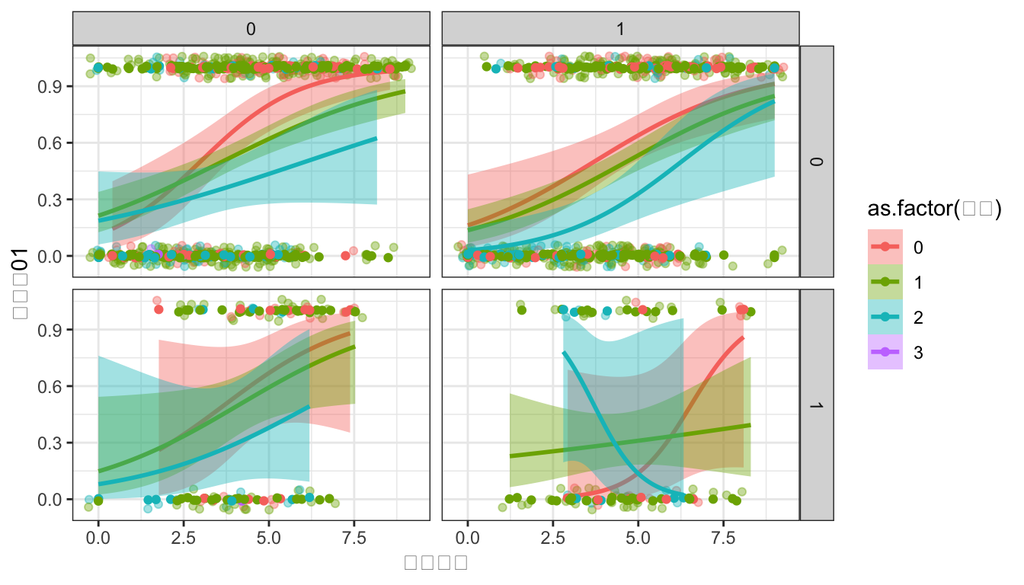

```r
graph3
```

## macの方はコチラを使ってください．

```r
graph3_mac<-空き巣調査 %>%
  ggplot(aes(x=不在時間, y=空き巣01,
             color=as.factor(会話), fill=as.factor(会話))) +
  geom_point(position=position_jitter(width=0.3,height=0.06),
             alpha=.4,shape=21,size=1.5) +
  stat_smooth(method="glm",
              method.args=list(family="binomial"),
              se=TRUE)+
  facet_grid(飼い犬01~ セキュリティ01)+
  geom_jitter(height=0.01, width = 0.01)+
  theme_bw(base_family = "YuGo-Medium")
```

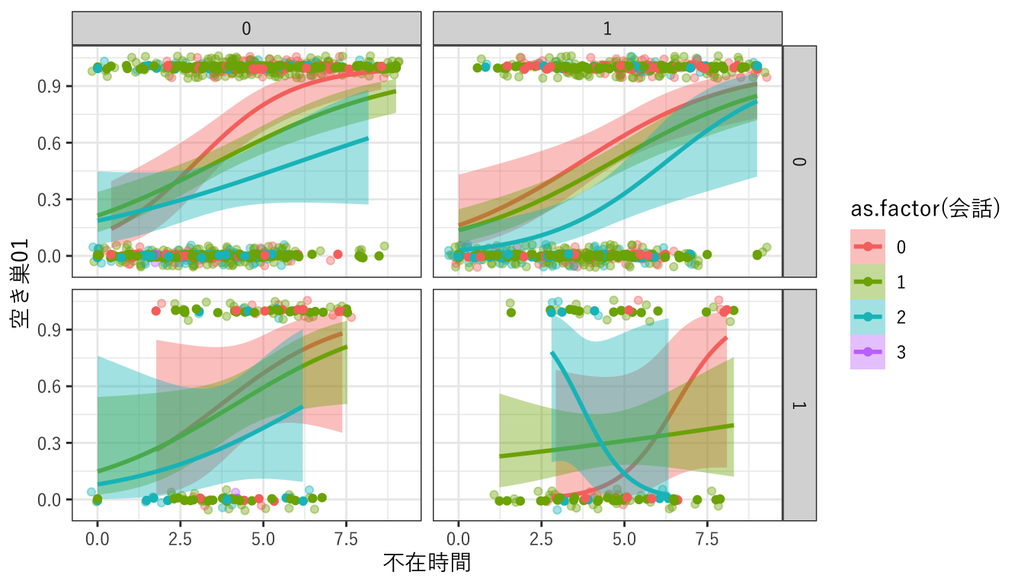

```r
graph3_mac
```

## ちなみに．．．．

```r
anova(modelfull_logi,　modelstep, test = "Chisq")
```

```
## Analysis of Deviance Table
##
## Model 1: 空き巣01 ~ 不在時間 + 会話 + 築年数 + セキュリティ01 +
##     飼い犬01
## Model 2: 空き巣01 ~ 不在時間 + 会話 + セキュリティ01 +
##     飼い犬01
##   Resid. Df Resid. Dev Df Deviance Pr(>Chi)
## 1       794     956.81
## 2       795     957.11 -1 -0.29394   0.5877
```

- anova()という関数で2つのモデルの妥当性を比較することができる．
  - 尤度比検定
  - 一般線形モデルの時と同様に評価できる．

## さらなる一般化線形モデルの説明

## ロジスティック回帰分析：

- 母集団の確率分布に2項分布を仮定する
- リンク関数にロジット関数を指定する．

## 2項分布

- 確率密度関数は以下の通りに示される．

\[_nC_k*p^k*(1-p)^{n-k}\]

- ただし，pを成功確率，nを試行回数，kを成功回数とする．
- また，\(_nC_k\)はコンビネーションと呼ばれ，n個の集団の中からk個を選ぶ場合の数を示す．

ex.売れる確率が0.2(=p)の商品が5つ(=n)あり，そのうち3つ(=k)が売れる確率は以下の通り．

\[_5C_3*p^3*(1-p)^{5-3}\]

- Rで計算してみる．

```r
choose(5, 3)
```

```
## [1] 10
```

```r
# choose関数は組み合わせの場合の数（コンビネーション）を計算する
```

```r
p <- 0.2
n <- 5
k <- 3
choose(n, k)*p^k*(1-p)^(n-k)
```

```
## [1] 0.0512
```

すでに用意されている専用の関数もある．

```r
dbinom(3, size=5, prob=0.2)
```

```
## [1] 0.0512
```

## ロジスティック回帰分析とロジット関数

- ロジスティック回帰分析は試行回数nがわかっている状況で，成功確率pを求める．
  - pは確率であるために0-1の値しかとらない．

\[p=\frac{1}{1+exp\{-(ax+b)\}}\]

- exp(X)：eのX乗
- 線形予測子(ax+b)が小さくなる→分母が大きくなる→成功確率が0に近づく
- 線形予測子(ax+b)が大きくなる→分母が小さくなる→成功確率が1に近づく
- ロジット関数：ロジスティック関数の逆関数．両辺にロジット関数を適用すると，線形予測子が見やすくなる．

\[ln(\frac{p}{1-p}) = ax + b\]

- 引き続き，教科書p.273からはじまる「11.6モデルの意味」を精読しておいてください．

## オッズ

- 失敗するよりも何倍成功しやすいか
  - ex.オッズが2であれば失敗するよりも2倍成功しやすい．
- 成功確率をpとするとオッズは**\(\frac{p}{1-p}\)**
  - ex. p=1/2であれば，成功確率と失敗確率は等しくなる：オッズは\(\frac{1/2}{1-(1/2)}=\frac{1/2}{1/2}=1\)
  - ex. p=3/4であれば失敗確率は1/4となる：オッズは\(\frac{3/4}{1-(3/4)}=\frac{3/4}{1/4}=3\)
- 対数オッズ：オッズにログをとったもの **\(ln(\frac{p}{1-p}\))**
- 実際には対数オッズは解釈しにくいためにexpをとってオッズに戻してから解釈する．

## 分析結果

- 選ばれたモデルを評価しましょう

```
Coefficients:
               Estimate Std. Error z value Pr(>|z|)
(Intercept)    -0.86580    0.24118  -3.590 0.000331 ***
不在時間        0.39338    0.04186   9.398  < 2e-16 ***
会話           -0.54989    0.13063  -4.209 2.56e-05 ***
セキュリティ01 -0.54917    0.15745  -3.488 0.000487 ***
飼い犬01       -0.48100    0.21421  -2.245 0.024740 *
```

```r
exp(modelstep$coefficients)
```

```
##    (Intercept)       不在時間           会話 セキュリティ01       飼い犬01
##      0.4207135      1.4819782      0.5770136      0.5774281      0.6181666
```

- 教科書p.273での報告例では「築年数」も入っているフルモデルが掲載されています．
- 今回はモデル選択をしたので築年数を除いたモデルを採択しているが，フルモデルと築年数を除いたモデルのいずれを報告しても構わない．
  - 実際には，フルモデルとモデル選択をしたこのモデルを並列して記述することになる．

## 演習問題：

## 演習問題

- ロジスティック回帰分析の解釈を練習しましょう．
- 余裕があれば，教科書p.283にある「章末演習」をやってみましょう．
  - データは入れておきます．